# IRS 527 Filings

Isaac Flath

2022-02-01T21:13:14-05:00

# Setup

## Imports

These are all standard imports that I use. I haven’t filtered out ones not used in this particular report, but these are my standard imports I start with on projects.

```r
library(DBI)

# general visualisation
library('ggplot2') # visualisation
library('scales') # visualisation
library('patchwork') # visualisation
library('RColorBrewer') # visualisation
library('corrplot') # visualisation
library('ggthemes') # visualisation
library('viridis') # visualisation
library('gt') # table styling

# general data manipulation
library('dplyr') # data manipulation
library('readr') # input/output
library('vroom') # input/output
library('tibble') # data wrangling
library('tidyr') # data wrangling
library('stringr') # string manipulation
library('forcats') # factor manipulation
library('janitor') # cleaning

# specific
library('glue') # encoding
library('naniar') # missing values
#library('gganimate') # visualisation
library('ggrepel') # visualisation
library('grid') # visualisation
library('GGally') # visualisation
library('ggforce') # visualisation
#library('ggtext') # visualisation
```

## UDFs

```r
`%notin%` <- Negate(`%in%`)
```

## Download and Unzip

The Data is availabe from the IRS website at this location `http://forms.irs.gov/app/pod/dataDownload/fullData`.

We need to download, unzip, and then pull the file out of the nested directory path.

Download and unzip the file to `FullDataFile.txt`

```r
output_path <- "~/code_outputs"
url = 'http://forms.irs.gov/app/pod/dataDownload/fullData'

dest_path = file.path(output_path,"irs527_fullData.zip")
if (!file.exists(dest_path)) {download.file(url,dest_path)}

unzip_path = file.path(output_path,"var")
if (!file.exists(unzip_path)){unzip(dest_path)}

from = file.path(output_path,"/var/IRS/data/scripts/pofd/download/FullDataFile.txt")
file_path = file.path(output_path,"FullDataFile.txt")
file.copy(from,file_path)
```

## File Head

From there we can look at the first few lines of the file. We can see a few things:

1. Not every row has the same number of fields.
2. The first cell has what type of row it is

This tells us that we are probably going to need to parse this row by row in some way, rather than using an out of the box read csv function.

```r
lines <- readLines(file_path, n=7)
writeLines(lines,sep="\n\n")
```

```
H|20220129|0311|F|

1|8871|8|0|0|0|912121950|Dan Swecker for Senate Campaign|10420 - 173rd Ave SW||Rochester|WA|98579||wfga@localaccess.com||Dan Swecker|10420 - 173rd Ave SW||Rochester|WA|98579||Dan Swecker|10420 - 173rd Ave. SW||Rochester|WA|98579||same||Rochester|WA|98579|||||Tax exempt political organization - Polit…

D|8|26174|Dan Swecker for Senate Campaign|912121950|Dan Swecker|Candidate|10420 - 173rd Ave. SW||Rochester|WA|98579||

1|8871|9|0|0|0|954857244|FRIENDS OF TOM CALDERON|728 W. EDNA PLACE||COVINA|CA|91722||no@email||YOLANDA MIRANDA|728 W. EDNA PLACE||COVINA|CA|91722||YOLANDA MIRANDA|728 W. EDNA PLACE||COVINA|CA|91722||728 W. EDNA PLACE||COVINA|CA|91722|||||RAISE FUNDS TO ELECT CANDIDATE||2001-05-14 15:05:31|1|1

D|9|269|FRIENDS OF TOM CALDERON|954857244|THOMAS M. CALDERON|CANDIDATE|412 N. 10TH STREET||MONTEBELLO|CA|90640||

D|9|270|FRIENDS OF TOM CALDERON|954857244|YOLANDA MIRAND|TREASURER|728 W. EDNA PLACE||COVINA|CA|91722||

1|8871|10|0|0|0|061596525|ASGM PAC|WILLIAM S WEBB CO INC|377 OAK ST - CS601|GARDEN CITY|NY|11530|0601|no@email||RICHARD C BLIVEN|377 OAK ST - CS601||GARDEN CITY|NY|11530|0601|RICHARD C BLIVEN|377 OAK ST - CS601||GARDEN CITY|NY|11530|0601|WILLIAM S WEBB CO INC|377 OAK ST - CS601|GARDEN CITY|NY|11530|…
```

# Structure Data

The structure of the file has different types of data indicated by the first letter of each row. In order to read this, we need to break it out into each files. There are several ways to do this

We additionally need to account for multi-line rows, where an individual row can span multiple lines.

## Split Files

First we split the file based on the first column. The idea is to take each line and drop it into another file, but there are some complications that we need to handle.

First, what would normally be a row in a dataframe is sometimes split among several lines. Because of this we cannot simply look row by row. To handle this we concatenate lines together while removing line breaks, and when we get to a new record start we dump it to the appropriate file.

```r
nlines <- read.table(pipe(paste("wc -l",file_path)))[[1]]

line_starts <- list('H|','F|','1|','2|','A|','B|','D|','E|','R|')

# open output files
out_files <- list()
for(line in line_starts){
  fpath <- file.path(output_path,paste(line,'.txt'))
  if (file.exists(fpath)) {
    print(paste("File Already Exists:",fpath))
    next
    } else {
    out_files[[line]] <- file(fpath,'w')
    }
}
```

```
## [1] "File Already Exists: ~/code_outputs/H| .txt"
## [1] "File Already Exists: ~/code_outputs/F| .txt"
## [1] "File Already Exists: ~/code_outputs/1| .txt"
## [1] "File Already Exists: ~/code_outputs/2| .txt"
## [1] "File Already Exists: ~/code_outputs/A| .txt"
## [1] "File Already Exists: ~/code_outputs/B| .txt"
## [1] "File Already Exists: ~/code_outputs/D| .txt"
## [1] "File Already Exists: ~/code_outputs/E| .txt"
## [1] "File Already Exists: ~/code_outputs/R| .txt"
```

```r
if(length(out_files) > 0){

  con <- file(file_path,"r")

  for(i in 0:nlines) {
    line <- str_replace_all(str_replace_all(readLines(con, n = 1), '\r', ''), '\n', '')

    if(identical(line,character(0))){
      writeLines(full_line, out_files[[out_type]])
      break}

    line_type <- substr(line,1,2)

    # handle starting line
    if(i==0){
      full_line <- line
      out_type <- line_type
      next
    }

    if(line_type %in% line_starts){
      if(out_type %in% names(out_files)){writeLines(full_line, out_files[[out_type]])}
      full_line <- line
      out_type <- line_type
    } else {
      full_line <- paste(full_line,line)
    }
    if(i%%100000 == 0){print(paste(Sys.time(),'|',i,'of',nlines))}
  }
  # close all files
  close(con)
  for (f in out_files) {close(f)}
}
```

## Column Map

When we load into the dataframe we need to give them column names to be useful. Because of how the files are structured, it does not include a header with column names so we need to take them from the data dictionary the provide.

```r
a <- c('record_type','form_id_number','sched_a_id','org_name','ein','contributor_name','contributor_address_1',
        'contributor_address_2','contributor_address_city','contributor_address_state','contributor_address_zip_code',
        'contributor_address_zip_ext','contributor_employer','contribution_amount','contributor_occupation',
        'agg_contribution_ytd','contribution_date')

one <- c('record_type','form_type','form_id_number','initial_report_indicator','amended_report_indicator','final_report_indicator','ein',
        'organization_name','mailing_address_1','mailing_address_2','mailing_address_city','mailing_address_state','mailing_address_zip_code',
        'mailing_address_zip_ext','e_mail_address','established_date','custodian_name','custodian_address_1','custodian_address_2',
        'custodian_address_city','custodian_address_state','custodian_address_zip_code','custodian_address_zip_ext','contact_person_name',
        'contact_address_1','contact_address_2','contact_address_city','contact_address_state','contact_address_zip_code','contact_address_zip_ext',
        'business_address_1','business_address_2','business_address_city','business_address_state','business_address_zip_code','business_address_zip_ext',
        'exempt_8872_indicator','exempt_state','exempt_990_indicator','purpose','material_change_date','insert_datetime','related_entity_bypass',
        'eain_bypass')

two <- c('record_type','form_type','form_id_number','period_begin_date','period_end_date','initial_report_indicator','amended_report_indicator','final_report_indicator',
          'change_of_address_indicator','organization_name','ein','mailing_address_1','mailing_address_2','mailing_address_city','mailing_address_state','mailing_address_zip_code',
          'mailing_address_zip_ext','e_mail_address','org_formation_date','custodian_name','custodian_address_1','custodian_address_2','custodian_address_city','custodian_address_state',
          'custodian_address_zip_code','custodian_address_zip_ext','contact_person_name','contact_address_1','contact_address_2','contact_address_city','contact_address_state',
          'contact_address_zip_code','contact_address_zip_ext','business_address_1','business_address_2','business_address_city','business_address_state','business_address_zip_code',
          'business_address_zip_ext','qtr_indicator','monthly_rpt_month','pre_elect_type','pre_or_post_elect_date','pre_or_post_elect_state','sched_a_ind','total_sched_a',
          'sched_b_ind','total_sched_b','insert_datetime')

b <- c('record_type','form_id_number','sched_b_id','org_name','ein','reciepient_name','reciepient_address_1','reciepient_address_2','reciepient_address_city','reciepient_address_st',
      'reciepient_address_zip_code','reciepient_address_zip_ext','reciepient_employer','expenditure_amount','recipient_occupation','expenditure_date','expenditure_purpose')

d <- c('record_type','form_id_number','director_id','org_name','ein','entity_name','entity_title','entity_address_1','entity_address_2','entity_address_city',
        'entity_address_st','entity_address_zip_code','entity_address_zip_code_ext')

e <- c('record_type','form_id_number','eain_id','election_authority_id_number','state_issued')

r <- c('record_type','form_id_number','entity_id','org_name','ein','entity_name','entity_relationship','entity_address_1','entity_address_2','entity_address_city',
      'entity_address_st','entity_address_zip_code','entity_address_zip_ext')

h <- c('record_type','transmission_date','transmission_time','file_id_modifier')
f <- c('record_type','transmission_date','transmission_time','record_count')

column_map <- list('H|'=h,
                   'F|'=f,
                   '1|'=one,
                   '2|'=two,
                   'A|'=a,
                   'B|'=b,
                   'D|'=d,
                   'E|'=e,
                   'R|'=r)
```

# Load Files

Now that we have our files split out we can handle them like normal csv files and load them into SQLite. Let’s start with loading all our data into a sqlite database and take a brief look at some of the data we have.

After that we will walk through each one and take a quick look at what’s there and a few fields that peaked my interest at first glanse, though won’t explore every field or go in a ton of depth

```r
con <- dbConnect(RSQLite::SQLite(), file.path(output_path,"irs.sqlite"))
tables <- dbListTables(con)
```

```r
load_map <- list("1|"="main_8871",
                 'D|'="directors_officers_8871",
                 'R|'="related_entities_8871",
                 'E|'="eain_8871",
                 "2|"="main_8872",
                 "A|"="schedule_a_8872",
                 "B|"="schedule_b_8872")

for(file_pref in names(load_map)){
  table_name <- load_map[[file_pref]]
  if(table_name %notin% tables){
    print(paste("Loading",file_pref,"into",table_name))
    df <- vroom(file.path(output_path,paste(file_pref,".txt")),col_names=column_map[[file_pref]])
    dbWriteTable(con, table_name, df, overwrite=TRUE)
  }
}

dbListTables(con)
```

## File Metadata

Each file has a header and footer row.

### Header Row

The file starts with a header row that just have general data about this particular data file.

```r
file_pref <- 'H|'
df <- vroom(file.path(output_path,paste(file_pref,".txt")),col_names=column_map[[file_pref]],n_max=1000)
gt(df %>% select(-X5))
```

| record_type | transmission_date | transmission_time | file_id_modifier |
| --- | --- | --- | --- |
| H | 20220129 | 0311 | FALSE |

### Footer Row

The files end with a fooder record that has data about the particular file, similar to the header.

```r
file_pref <- 'F|'
df <- vroom(file.path(output_path,paste(file_pref,".txt")),col_names=column_map[[file_pref]],n_max=1000)
gt(df %>% select(-X5))
```

[output not shown]

## 8871 Data

### 8871 Main Form

The 8871 form is where 527 organizations submit data about their company. In this header form we see a lot of basic information you would expect on any company record such as addresses, contact information, purpose, and ID numbers.

```r
df <- dbGetQuery(con, 'SELECT * FROM main_8871')

df <- df %>%
  mutate(across(c(exempt_state, business_address_state,contact_address_state,custodian_address_state,mailing_address_state,established_date), as.factor))
# %>%
#   mutate(across(c(initial_report_indicator, amended_report_indicator,final_report_indicator,
#                   exempt_8872_indicator,related_entity_bypass,eain_bypass), as.logical))
```

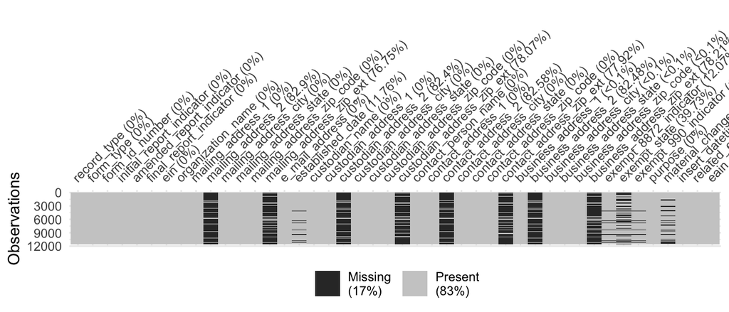

```r
df %>%
  sample_frac(0.2) %>%
  naniar::vis_miss()
```

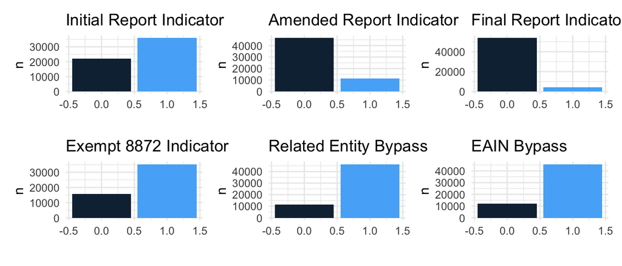

```r
p1 <- df %>%
  filter(!is.na(initial_report_indicator)) %>%
  count(initial_report_indicator) %>%
  ggplot(aes(initial_report_indicator, n, fill = initial_report_indicator)) +
  geom_col() +
  theme_minimal() +
  theme(legend.position = "none") +
  labs(x = "", title = "Initial Report Indicator")
p2 <- df %>%
  filter(!is.na(amended_report_indicator)) %>%
  count(amended_report_indicator) %>%
  ggplot(aes(amended_report_indicator, n, fill = amended_report_indicator)) +
  geom_col() +
  theme_minimal() +
  theme(legend.position = "none") +
  labs(x = "", title = "Amended Report Indicator")

p3 <- df %>%
  filter(!is.na(final_report_indicator)) %>%
  count(final_report_indicator) %>%
  ggplot(aes(final_report_indicator, n, fill = final_report_indicator)) +
  geom_col() +
  theme_minimal() +
  theme(legend.position = "none") +
  labs(x = "", title = "Final Report Indicator")

p4 <- df %>%
  filter(!is.na(exempt_8872_indicator)) %>%
  count(exempt_8872_indicator) %>%
  ggplot(aes(exempt_8872_indicator, n, fill = exempt_8872_indicator)) +
  geom_col() +
  theme_minimal() +
  theme(legend.position = "none") +
  labs(x = "", title = "Exempt 8872 Indicator")

p5 <- df %>%
  filter(!is.na(related_entity_bypass)) %>%
  count(related_entity_bypass) %>%
  ggplot(aes(related_entity_bypass, n, fill = related_entity_bypass)) +
  geom_col() +
  theme_minimal() +
  theme(legend.position = "none") +
  labs(x = "", title = "Related Entity Bypass")


p6 <- df %>%
  filter(!is.na(eain_bypass)) %>%
  count(eain_bypass) %>%
  ggplot(aes(eain_bypass, n, fill = eain_bypass)) +
  geom_col() +
  theme_minimal() +
  theme(legend.position = "none") +
  labs(x = "", title = "EAIN Bypass")

(p1 + p2 + p3) / (p4 + p5 + p6)
```

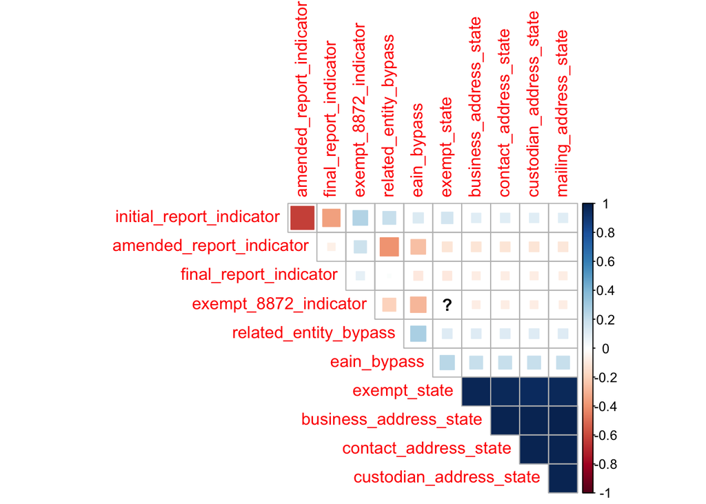

```r
df %>%
  select(initial_report_indicator, amended_report_indicator,final_report_indicator,exempt_8872_indicator,related_entity_bypass,eain_bypass,exempt_state, business_address_state,contact_address_state,custodian_address_state,mailing_address_state) %>%
  replace_na(list(initial_report_indicator=-1, amended_report_indicator=-1,final_report_indicator=-1,exempt_8872_indicator=-1,related_entity_bypass=-1,eain_bypass=-1,exempt_state=-1, business_address_state=-1,contact_address_state=-1,custodian_address_state=-1,mailing_address_state=-1)) %>%
  mutate(across(everything(), as.numeric)) %>%
  cor(use = "pairwise.complete.obs", method = "spearman") %>%
  corrplot(type = "upper", diag = FALSE, method = "square")
```

### Directors/Officers (8871)

These records are included with 8871 forms and shows directors and officers of the 527 organization. Of course, there can be many directors or officers in one organization.

```r
df <- dbGetQuery(con, 'SELECT * FROM directors_officers_8871')
```

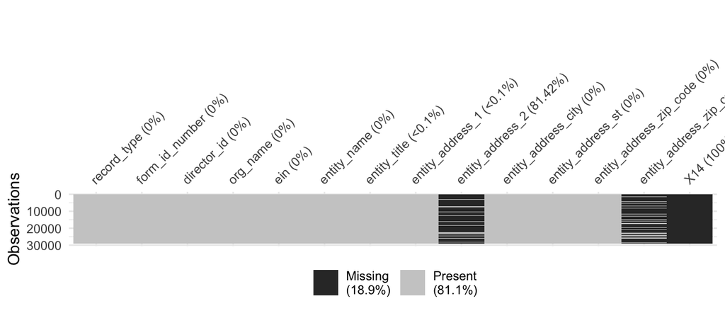

```r
df %>%
  sample_frac(0.2) %>%
  naniar::vis_miss()
```

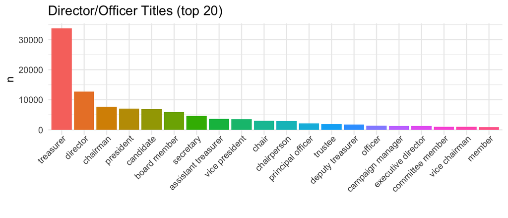

```r
df %>%
  mutate(entity_title=tolower(entity_title)) %>%
  count(entity_title) %>%
  arrange(desc(n)) %>%
  head(20) %>%
  mutate(entity_title=factor(entity_title,levels=entity_title)) %>%
  ggplot(aes(entity_title, n, fill = entity_title)) +
  geom_col() +
  theme_minimal() +
  theme(legend.position = "none",axis.text.x = element_text(angle = 45, vjust = 1.1, hjust=1)) +
  labs(x = "", title = "Director/Officer Titles (top 20)")
```

### Related Entities (8871)

These records are included with 8871 forms and showsrelated entities to the 527 organization. Of course, there can be many related entities on one form.

```r
df <- dbGetQuery(con, 'SELECT * FROM related_entities_8871')
```

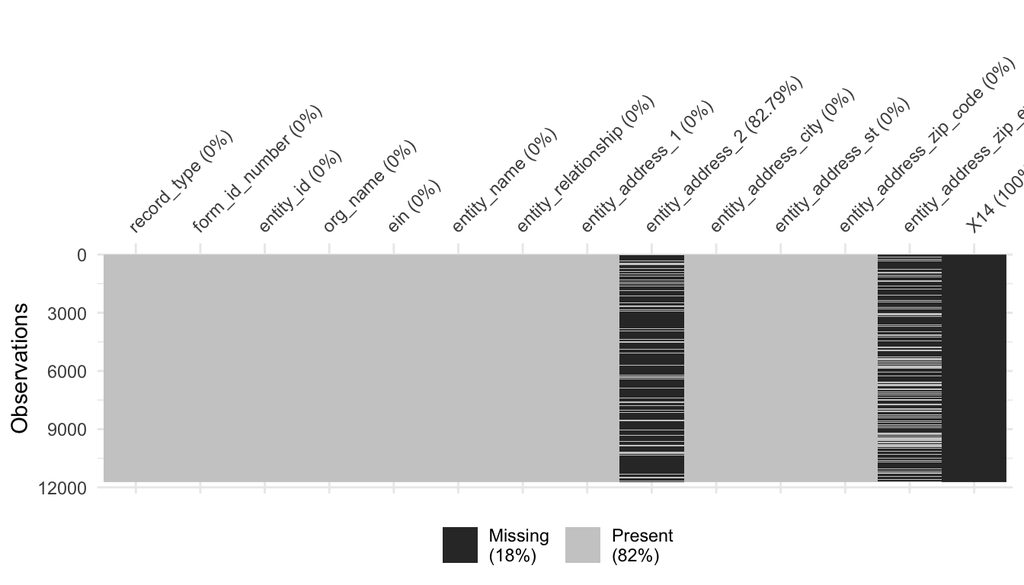

```r
df %>%
  sample_frac(0.2) %>%
  naniar::vis_miss()
```

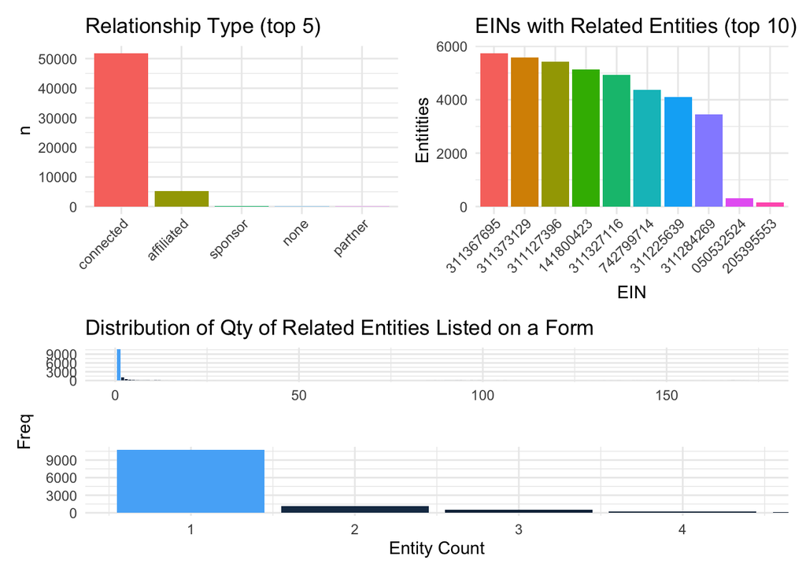

```r
p1 <- df %>%
  select(entity_id,entity_name,entity_relationship,org_name) %>%
  mutate(entity_name=tolower(entity_name),
         entity_relationship=tolower(entity_relationship),
         org_name=tolower(org_name)) %>%
  count(entity_relationship) %>%
  arrange(desc(n)) %>%
  head(5) %>%
  mutate(entity_relationship=factor(entity_relationship,levels=entity_relationship)) %>%
  ggplot(aes(entity_relationship, n, fill = entity_relationship)) +
  geom_col() +
  theme_minimal() +
  theme(legend.position = "none",axis.text.x = element_text(angle = 45, vjust = 1.1, hjust=1)) +
  labs(x = "", title = "Relationship Type (top 5)")


p2 <- df %>%
  select(ein,entity_id) %>%
  group_by(ein) %>%
  summarise(entity_id=n_distinct(entity_id)) %>%
  arrange(desc(entity_id)) %>%
  head(10) %>%
  mutate(ein=factor(ein,levels=ein)) %>%
  ggplot(aes(ein, entity_id, fill = ein)) +
  geom_col() +
  theme_minimal() +
  theme(legend.position = "none",axis.text.x = element_text(angle = 45, vjust = 1.1, hjust=1)) +
  labs(x = "EIN", y="Entitities", title = "EINs with Related Entities (top 10)")

p3 <- df %>%
  select(form_id_number,entity_id) %>%
  group_by(form_id_number) %>%
  summarise(entity_cnt=n_distinct(entity_id)) %>%
  group_by(entity_cnt) %>%
  summarise(cnt=n_distinct(form_id_number)) %>%
  ggplot(aes(entity_cnt, cnt, fill=cnt)) +
  geom_bar(stat='identity') +
  theme_minimal() +
  theme(legend.position = "none") +
  labs(x = "Entity Count", y="Freq", title = "Distribution of Qty of Related Entities Listed on a Form") +
  facet_zoom(x=entity_cnt < 5)

(p1+p2) / p3
```

### EAIN (8871)

EAIN are the Election Authority Identification numbers listed on the 8871 form.

```r
df <- dbGetQuery(con, 'SELECT * FROM eain_8871')
```

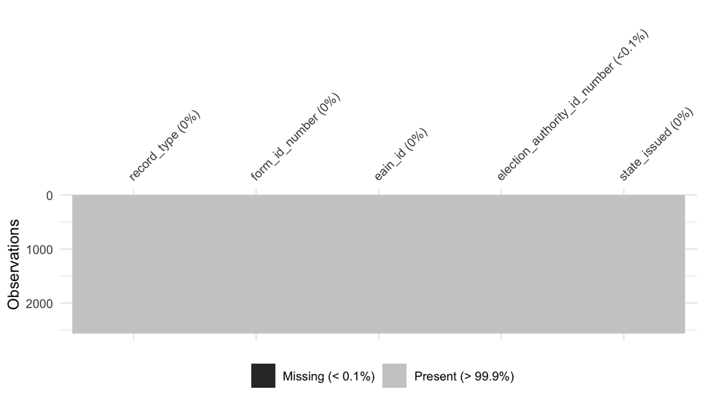

```r
df %>%
  select(-X6) %>%
  sample_frac(0.2) %>%
  naniar::vis_miss()
```

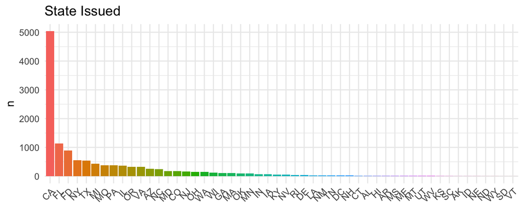

```r
df %>%
  select(state_issued) %>%
  count(state_issued) %>%
  arrange(desc(n)) %>%
  # head(5) %>%
  mutate(state_issued=factor(state_issued,levels=state_issued)) %>%
  ggplot(aes(state_issued, n, fill = state_issued)) +
  geom_col() +
  theme_minimal() +
  theme(legend.position = "none",axis.text.x = element_text(angle = 45, vjust = 1.1, hjust=1)) +
  labs(x = "", title = "State Issued")
```